# Step-by-step guide in R: Estimation of planned and unplanned missing individual scores in longitudinal designs using continuous-time state-space models

This is a step-by-step guide to explain the procedure proposed in the paper *“Estimation of planned and unplanned missing individual scores in longitudinal designs using continuous-time state-space models”* (https://doi.org/10.1037/met0000664). This guide aims to explain how to estimate a CT-SSM-LCS model and how to compute the RTS smoothed Kalman scores for data sets with missing data.

*IMPORTANT*: The R syntax and the structure of the data set should be accommodated to the objective of the particular study where this methodology is going to be applied.

## 0. Download the simulated data set

In order to reproduce this example, you need to download this simulated data set: https://github.com/jamartinezhuertas/RTS-KS/blob/main/data.rds.

## 1. Load the required R packages

```r
library(OpenMx)
library(dplyr)
```

## 2. Prepare the matrices for the CT-LCS-SSM

First, we need to prepare invariant part of the OpenMx SSM models. The model includes seven parameters (see the main manuscript for an explanation of their interpretation. See Hunter, 2018, for an explanation of the model matrices):

- Self-feedback $\beta$, included in matrix `A` with name `b_y`.
- Mean of the initial latent level $μ_{y0}$, included in matrix `x0` with name `y0mn`.
- Mean of the latent additive component $μ_{ya}$, included in matrix `x0` with name `yAmn`.
- Variance of the initial level $σ^2_{y0}$, included in matrix `P0` with name `y0v`.
- Variance of the additive component $σ^2_{ya}$, included in matrix `P0` with name `yAv`.
- Covariance between initial level and additive component $σ_{0,a}$, included in matrix `P0` with name `y0Acv`.
- Measurement error variance $σ^2_e$, included in matrix `R` with name `MerY`.

```r
opmxL <- list()

# Matrix A. Latent dynamics
opmxL$amat_ct <- mxMatrix(name = "A", "Full", 2, 2, free = c(TRUE,FALSE,FALSE,FALSE),
                          values = c(-.2,0,1,0),
                          dimnames = list( c("y0", "yA"), c("y0", "yA") ),
                          labels = c("b_y", NA,NA,NA),
                          lbound = c(-1, NA,NA,NA),
                          ubound = c(0, NA,NA,NA))

# Matrix B. Effects of time-varying covariates on latent variables (null in our model)
opmxL$bmat <- mxMatrix(name = "B", "Zero", 2, 1)

# Matrix C. Measurement model linking latent and observed variables
opmxL$cmat <- mxMatrix(name = "C", "Full", 1, 2, free = FALSE,
                       values = c(1,0),
                       dimnames = list( c("y"), c("y0", "yA") ),
                       labels = c(NA, NA)  )

# Matrix D. Effects of time-varying covariates on observed variables (null in our model)
opmxL$dmat <- mxMatrix("Zero", 1, 1, name = "D")

# Matrix Q. Covariance matrix for the dynamic error (i.e., latent innovations)
opmxL$qmat <- mxMatrix("Zero", 2, 2, name = "Q")

# Matrix R. Covariance matrix for the measurement error
opmxL$rmat <- mxMatrix("Diag", 1, 1, TRUE, 2,
                       name = "R", labels = "MerY")

# Matrix x0. Means of the initial latent levels
opmxL$xmat <- mxMatrix(name = "x0", "Full", 2, 1, free = TRUE,
                       values = c(12, 7),
                       labels = c("y0mn", "yAmn"))

# Matrix P0. Covariance of the initial latent levels
opmxL$pmat <- mxMatrix(name = "P0", "Symm", 2, 2, TRUE,
                       values = c(25, 3, .4),
                       labels = c("y0v", "y0Acv", "yAv"),
                       lbound = c(0, NA, 0))

# Matrix u. Values of the time-varying covariates (null in our model)
opmxL$umat <- mxMatrix("Zero", 1, 1, name = "u")

# Matrix t. Variable in the data set with the times at which measurement happened.
opmxL$tmat <- mxMatrix('Full', 1, 1, name='time', labels='data.age')
```

Once the SSM matrices have been defined, we store them in the object `opmxL$modL_ct`. Then we create the expectation continuous-time SSM object, specifying the names of the matrices in `opmxL$expODE`.

```r
opmxL$modL_ct <- with(opmxL, list(amat_ct, bmat, cmat, dmat,
                                  qmat, rmat, xmat, pmat,
                                  umat, tmat))

opmxL$expODE <- mxExpectationStateSpaceContinuousTime(A = "A", B = "B",
                                                      C = "C", D = "D",
                                                      Q = "Q", R = "R",
                                                      x0 = "x0", P0 = "P0",
                                                      u = "u", t = "time")
```

So far, we have defined a n=1 model. The following function will be used later for creating creating this model for each individual in the sample.

```r
genMxIndModels_ct <- function(x, dwork, modNames_ct) {
  DataSetForSubjectK <- dwork[[x]]
  ctModel <- opmxL$modL_ct
  indivmodels <- mxModel(name = modNames_ct[x],
                         ctModel,
                         opmxL$expODE,
                         mxFitFunctionML(),
                         mxData(DataSetForSubjectK, type ='raw')  )  }
```

## 3. Read your data set (and tips for imputing missing data points)

Now we load the data set we want to analyze. In this example, we use a simulated data set with 200 participants in an accelerated longitudinal designs (ALD) with no unplanned data missingness (it can be downloaded at the beginning of this document) :

```r
data <- readRDS("data.rds")
```

Three characteristics of these example data are worth noting:

1. The simulated accelerated longitudinal design has three observations per individual, are measured in three alternate years. See the main text for a full explanation of this design.
2. The information of the individual measurements is: (1) the time point at which the measurement was taken (`age`, with *age*=0 for five years), and (2) the observed score of the variable (`y`).
3. In addition to the rows with observed measures, we included several rows with additional time points without observed information (i.e., missing observations in variable `y`). We will impute the latent true levels at these specific time points *t*. Note that the rows need to be ordered by the time variable.

```r
data[[1]]
```

| id | y | age |
| --- | --- | --- |
| 1 | 9.624999 | 0.2307692 |
| 1 | NA | 1.7884615 |
| 1 | 16.162354 | 2.6346154 |
| 1 | NA | 3.6923077 |
| 1 | 21.255317 | 4.5000000 |
| 1 | NA | 5.2307692 |
| 1 | NA | 6.3076923 |
| 1 | NA | 7.5000000 |
| 1 | NA | 8.5961538 |
| 1 | NA | 9.8461538 |

[output cut: 5 more lines]

## 4. Estimate the CT-SSM-LCS model

Now, we estimate the CT-SSM-LCS model.

```r
# Create individual models
cases <- seq(1,length(data))
modNames_ct <- paste0("i", cases, "ODE")
indivmodels_ct <- lapply(cases, genMxIndModels_ct, data, modNames_ct)
# Create multiple-subject model
multiSubjODE <- mxModel(name = "MultiODE", indivmodels_ct,
                        mxFitFunctionMultigroup(modNames_ct))
# Fit the model
multiSubjODERun <- mxRun(multiSubjODE)
# Examine group-level results
multiSubjODEsumm <- summary(multiSubjODERun)
multiSubjODEsumm$parameters
```

|  | name | matrix | row | col | Estimate | Std.Error | lbound | ubound | lboundMet | uboundMet |
| --- | --- | --- | --- | --- | --- | --- | --- | --- | --- | --- |
| 1 | b_y | i1ODE.A | y0 | y0 | -0.2452518 | 0.01653362 | -1 | 0 | FALSE | FALSE |
| 2 | MerY | i1ODE.R | 1 | 1 | 2.2221388 | 0.23878034 | NA | NA | FALSE | FALSE |
| 3 | y0mn | i1ODE.x0 | 1 | 1 | 9.1201998 | 0.53438809 | NA | NA | FALSE | FALSE |
| 4 | yAmn | i1ODE.x0 | 2 | 1 | 7.4797264 | 0.39100849 | NA | NA | FALSE | FALSE |
| 5 | y0v | i1ODE.P0 | 1 | 1 | 24.6600331 | 4.12795396 | 0 | NA | FALSE | FALSE |
| 6 | y0Acv | i1ODE.P0 | 1 | 2 | 3.9757638 | 0.78105565 | NA | NA | FALSE | FALSE |
| 7 | yAv | i1ODE.P0 | 2 | 2 | 1.3637353 | 0.24683388 | 0 | NA | FALSE | FALSE |

```r
# Obtain individual-level Kalman Scores
ks <- lapply(X = multiSubjODERun@submodels,
             FUN = mxKalmanScores, frontend=FALSE )
```

In this example, the names of the individual models have the format `ixODE`, where `x` represents the ID of the participant. For example, the results for individuals 1 and 2 are labeled as `i1ODE` and `i2ODE`, respectively. More info can be found in the documentation of the functions `mxKalmanScores` and `mxExpectationStateSpaceContinuousTime`, and in Hunter (2018). The function `mxKalmanScores` return, for each individual, a list with several objects. Of interest here are Rauch-Tung-Striebel (RTS) smoothed latent scores which are the estimated Kalman scores, stored in `xSmoothed`, and their corresponding error covariance matrices `PSmoothed`, which provide a measure of the estimation uncertainty.

```r
str(ks$i1ODE)
```

[output not shown]

## 5. Compute the RTS smoothed Kalman scores

Now we illustrate how to compute the RTS smoothed Kalman scores for the first individual in the data set. To do so, we need to specify the index or name of the individual in the following function. In `model` we provide the estimated model for the individual of interest. In `data` we provide the dataset with the observed scores and the additional rows with the time points at which the latent variables should be estimated. Note that our model includes two latent variables: time-varying the level (first column) and the time-invariant additive component (second column). Therefore, estimates of the unobserved ability level are stored in the first column.

```r
id <- 1
(cKsId <- mxKalmanScores(model = multiSubjODERun@submodels[[id]], data = data[[id]])$xSmoothed)
```

```
## Computing Kalman scores in frontend R.  This may take a few seconds.
```

```
##            [,1]     [,2]
##  [1,]  8.055989 7.308151
##  [2,]  9.210740 7.294178
##  [3,] 15.209991 6.973313
##  [4,] 17.203232 6.740263
##  [5,] 19.597583 6.760903
##  [6,] 21.080069 6.780692
##  [7,] 22.157716 6.780692
##  [8,] 23.432075 6.780692
##  [9,] 24.500958 6.780692
## [10,] 25.242781 6.780692
## [11,] 25.877797 6.780692
## [12,] 25.951360 6.780692
## [13,] 26.381499 6.780692
## [14,] 26.779519 6.780692
## [15,] 26.850196 6.780692
## [16,] 27.145425 6.780692
```

Now we combine the Kalman scores with the original data set for the individual, where `age` is the age at the different time points, `y_observed` stores the observed values (in this case, we have only three observations per individual), and `y_KS` stores the predicted RTS smoothed Kalman score for each time point.

```r
data_ind <- as.data.frame(cbind(data[[id]]$age, data[[id]]$y, cKsId[-1,1])) # The first row of cKsId must be removed
colnames(data_ind) <- c("age", "y_observed", "y_KS")
(data_ind)
```

| age | y_observed | y_KS |
| --- | --- | --- |
| 0.2307692 | 9.624999 | 9.21074 |
| 1.7884615 | NA | 15.20999 |
| 2.6346154 | 16.162354 | 17.20323 |
| 3.6923077 | NA | 19.59758 |
| 4.5000000 | 21.255317 | 21.08007 |
| 5.2307692 | NA | 22.15772 |
| 6.3076923 | NA | 23.43207 |
| 7.5000000 | NA | 24.50096 |
| 8.5961538 | NA | 25.24278 |
| 9.8461538 | NA | 25.87780 |

[output cut: 5 more lines]

The function `mxKalmanScores` also provides the error associated to each Kalman score in the object `PSmoothed`. These errors can be used to compute the confidence interval for each time point.

```r
alpha <- .05 # (1 - confidence level)
qZ <- qnorm(p = 1-(alpha/2))
CI <- matrix(data = NA, ncol = 2, nrow = nrow(data_ind))
errors <- sqrt(mxKalmanScores(model = multiSubjODERun@submodels[[id]],
                              data = data[[id]])$PSmoothed[1,1,2:(nrow(data_ind)+1)])
CI[,1] <- data_ind$y_KS + qZ*errors
CI[,2] <- data_ind$y_KS - qZ*errors
CI <- as.data.frame(CI)
CI <- cbind(CI, data_ind$age)
colnames(CI) <- c("Upp", "Low", "age")
(CI)
```

| Upp | Low | age |
| --- | --- | --- |
| 11.84278 | 6.578695 | 0.2307692 |
| 17.88398 | 12.536004 | 1.7884615 |
| 19.37186 | 15.034607 | 2.6346154 |
| 21.90984 | 17.285324 | 3.6923077 |
| 23.18493 | 18.975208 | 4.5000000 |
| 24.43857 | 19.876861 | 5.2307692 |
| 25.94247 | 20.921674 | 6.3076923 |
| 27.21774 | 21.784177 | 7.5000000 |
| 28.10869 | 22.376874 | 8.5961538 |
| 28.87457 | 22.881025 | 9.8461538 |

[output cut: 5 more lines]

## 6. Graphical representation of the RTS smoothed Kalman scores

First we combine the rows of all the individuals into a single data frame.

```r
data_long <- as.data.frame(do.call(rbind, data))
data_long <- data_long[!is.na(data_long$y),]
```

Now we present a plot that includes, for the individual of interest:

- The RTS smoothed Kalman scores estimates (blue dashed line)
- The confidence interval (blue shaded region)
- The observed scores (black line and points)
- For the rest of the sample, observed trajectories (grey lines).

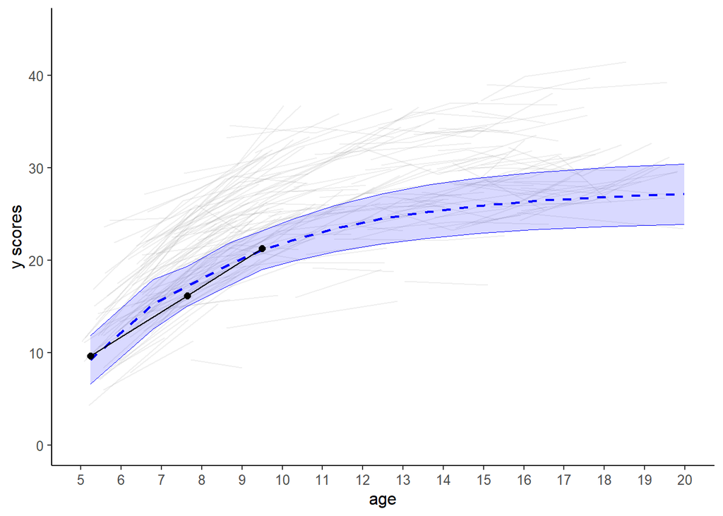

```r
library(ggplot2)

ggplot() +

    # Group trajectories
    geom_line(data = data_long, aes(x=age+5, y=y, group=id), colour = "dark grey", alpha=0.2)+

    # CI for KS
    geom_line(data=CI, aes(x=data_ind$age+5, y=Upp), size = 0.2, color='blue') +
    geom_line(data=CI, aes(x=data_ind$age+5, y=Low), size = 0.2, color='blue') +
    geom_ribbon(aes(x=CI$age+5, ymax= CI$Upp, ymin= CI$Low),
                fill="blue", alpha=.15) +

    # KS estimated latent scores
    geom_line(data=data_ind, aes(x=age+5, y=y_KS), size = .8, color='blue', linetype = "dashed") +

    ## Observed scores
    geom_point(data=data_ind, aes(x=age+5, y=y_observed), size = 2) +
    geom_line(data=data_ind[!is.na(data_ind$y_observed),], aes(x=age+5, y=y_observed, group=1)) +

    scale_x_continuous(breaks=seq(5, 20, 1)) +
    ylim(0,45) + ylab("y scores") + xlab("age") +
    theme_classic(base_size = 12, base_line_size = 0.5)
```